# Healthcare Analytics: Breast Cancer Classification Using Machine Learning Models (Decision tree)

Kelly Adu - Gyamfi

2025-10-25

# 1 Data Description

**Original reference:**  
Wolberg, W. H., & Mangasarian, O. L. (1990). *Multisurface method of pattern separation for medical diagnosis applied to breast cytology.* *Proceedings of the National Academy of Sciences*, 87(23), 9193–9196.  
https://archive.ics.uci.edu/ml/datasets/Breast+Cancer+Wisconsin+(Original)

**Data Generation/Collection:**  
The data were collected from the University of Wisconsin Hospitals, Madison, by Dr. William H. Wolberg. Cytological measurements were taken directly from digitized images of fine needle aspirate samples. Each feature is an integer value ranging from 1 to 10, representing the degree of cell abnormality. The dataset is widely used for supervised learning and binary classification benchmarking.

# 2 Formulating Practical and Analytical Questions

Developing predictive models for breast cancer diagnosis requires translating real-world clinical needs into structured analytical questions. The goal is to use these measurable features to support early cancer detection through accurate and interpretable classification models.

## 2.1 **Practical Questions**

1. Can cytological characteristics of breast cell nuclei reliably predict whether a tumor is **benign or malignant**?
2. Which **features** contribute most to distinguishing malignant from benign tumors?
3. Which **modeling approach** (logistic regression, neural network, decision tree, or ensemble) yields the **most accurate and interpretable** results?
4. How can model predictions be **optimized** to minimize misclassification, especially false negatives (malignant cases predicted as benign)?
5. Can predictive analytics assist healthcare professionals in making **early and cost-effective** diagnostic decisions?

## 2.2 **Analytical Questions**

1. Can a **binary classification model** accurately predict tumor type (*benign* vs. *malignant*) based on cytological features?
2. Which predictor variables show the **strongest statistical or computational influence** on malignancy?
3. How do **performance metrics** (ROC-AUC, accuracy, sensitivity, specificity, and F1-score) differ among the candidate models?
4. Can **neural network architectures** (e.g., perceptrons with different activation functions) outperform classical models like logistic regression?
5. Can **decision trees** and **bagging ensembles** improve performance by addressing nonlinearity and reducing model variance?
6. Which **optimal threshold** maximizes diagnostic effectiveness while minimizing clinical misclassification costs?

# 3 Methodology

## 3.1 Research Design and Analytical Framework

This study employs a comparative predictive modeling approach to develop and evaluate multiple machine learning algorithms for breast cancer classification. The methodology follows a systematic pipeline encompassing data preprocessing, exploratory analysis, model development, evaluation, and interpretation.

```r
methodology_steps <- data.frame(
  Step = c("1. Data Collection & Preprocessing",
           "2. Exploratory Data Analysis",
           "3. Model Development",
           "4. Model Evaluation",
           "5. Results Interpretation"),
  Description = c("Data cleaning, normalization, and train-test splitting",
                  "Feature distributions, correlations, and class imbalance analysis",
                  "Implementation of four classification algorithms with hyperparameter tuning",
                  "Performance comparison using multiple metrics and statistical tests",
                  "Feature importance analysis and clinical implications")
)

kable(methodology_steps, caption = "Table 2: Research Methodology Steps") %>%
  kable_styling(bootstrap_options = c("striped", "hover")) %>%
  column_spec(1, bold = TRUE)
```

Table 2: Research Methodology Steps

Step

Description

1. Data Collection & Preprocessing

Data cleaning, normalization, and train-test splitting

2. Exploratory Data Analysis

Feature distributions, correlations, and class imbalance analysis

3. Model Development

Implementation of four classification algorithms with hyperparameter tuning

4. Model Evaluation

Performance comparison using multiple metrics and statistical tests

5. Results Interpretation

Feature importance analysis and clinical implications

# 4 Feature Engineering

```r
# Feature engineering based on EDA insights
feature_engineering <- function(data) {
  engineered_data <- data %>%
    mutate(
      # Feature discretization based on clinical relevance
      Cell.size.cat = cut(Cell.size,
                         breaks = c(0, 2, 5, 10),
                         labels = c("Low", "Medium", "High")),
      Cl.thickness.cat = cut(Cl.thickness,
                            breaks = c(0, 3, 6, 10),
                            labels = c("Thin", "Medium", "Thick")),
      Bare.nuclei.cat = cut(Bare.nuclei,
                           breaks = c(0, 2, 5, 10),
                           labels = c("Few", "Moderate", "Many")),

      # Feature transformations
      Cell.size.sqrt = sqrt(Cell.size + 1),
      Cl.thickness.log = log(Cl.thickness + 1),

      # Feature creation: composite scores
      Nuclear.abnormality.score = (Cell.size + Cell.shape + Bare.nuclei) / 3,
      Structural.abnormality.score = (Cl.thickness + Marg.adhesion + Epith.c.size) / 3,

      # Risk score based on correlation insights
      High.risk.features = (Cell.size > 5) + (Cell.shape > 5) + (Bare.nuclei > 5) +
                          (Cl.thickness > 5) + (Bl.cromatin > 5)
    )

  return(engineered_data)
}

# Apply feature engineering
BreastCancer_engineered <- feature_engineering(BreastCancer_clean)

# Display new features
cat("New engineered features:\n")
```

```
## New engineered features:
```

```r
new_features <- setdiff(names(BreastCancer_engineered), names(BreastCancer_clean))
print(new_features)
```

```
## [1] "Cell.size.cat"                "Cl.thickness.cat"
## [3] "Bare.nuclei.cat"              "Cell.size.sqrt"
## [5] "Cl.thickness.log"             "Nuclear.abnormality.score"
## [7] "Structural.abnormality.score" "High.risk.features"
```

```r
# 3. Detect abnormal patterns and outliers
detect_abnormal_patterns <- function(data) {
  # Z-score analysis for outliers
  z_scores <- scale(data[,1:9])
  outliers <- apply(z_scores, 2, function(x) sum(abs(x) > 3))

  # Feature ranges and variability
  feature_stats <- data.frame(
    Feature = names(data[,1:9]),
    Min = sapply(data[,1:9], min),
    Max = sapply(data[,1:9], max),
    Mean = sapply(data[,1:9], mean),
    SD = sapply(data[,1:9], sd),
    Outliers_3SD = outliers
  )

  return(feature_stats)
}

abnormal_patterns <- detect_abnormal_patterns(BreastCancer_clean)
kable(abnormal_patterns, caption = "Feature Statistics and Outlier Detection") %>%
  kable_styling(bootstrap_options = c("striped", "hover"))
```

Feature Statistics and Outlier Detection

|  | Feature | Min | Max | Mean | SD | Outliers_3SD |
| --- | --- | --- | --- | --- | --- | --- |
| Cl.thickness | Cl.thickness | 1 | 10 | 4.442167 | 2.820761 | 0 |
| Cell.size | Cell.size | 1 | 10 | 3.150805 | 3.065145 | 0 |
| Cell.shape | Cell.shape | 1 | 10 | 3.215227 | 2.988581 | 0 |
| Marg.adhesion | Marg.adhesion | 1 | 10 | 2.830161 | 2.864562 | 0 |
| Epith.c.size | Epith.c.size | 1 | 10 | 3.234261 | 2.223085 | 31 |
| Bare.nuclei | Bare.nuclei | 1 | 10 | 3.544656 | 3.643857 | 0 |
| Bl.cromatin | Bl.cromatin | 1 | 10 | 3.445095 | 2.449697 | 0 |
| Normal.nucleoli | Normal.nucleoli | 1 | 10 | 2.869693 | 3.052666 | 0 |
| Mitoses | Mitoses | 1 | 9 | 1.582723 | 1.636316 | 31 |

# 5 Exploratoty data analysis

## 5.1 Feature distributions by class

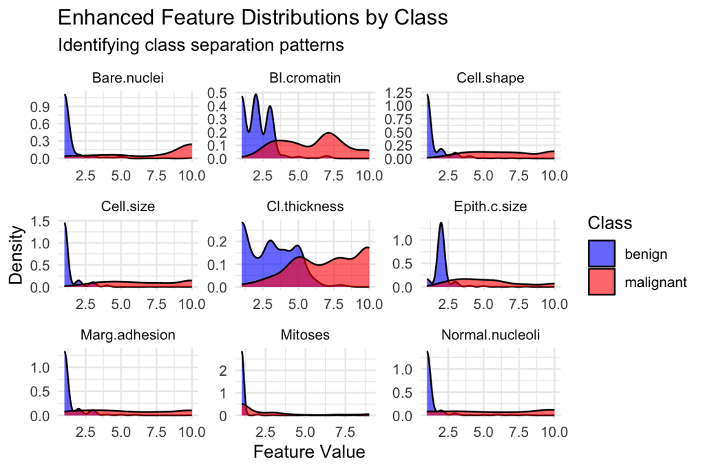

```r
feature_distribution_analysis <- function(data) {
  data_long <- data %>%
    pivot_longer(-c(Class, Class_binary), names_to = "Feature", values_to = "Value")

  ggplot(data_long, aes(x = Value, fill = Class)) +
    geom_density(alpha = 0.6) +
    facet_wrap(~Feature, scales = "free") +
    theme_minimal() +
    labs(title = "Enhanced Feature Distributions by Class",
         subtitle = "Identifying class separation patterns",
         x = "Feature Value", y = "Density") +
    scale_fill_manual(values = c("benign" = "blue", "malignant" = "red"))
}

feature_distribution_analysis(BreastCancer_clean)
```

### 5.1.1 Summary of Key Observations from Feature Distributions

The density plots reveal clear class separation patterns between benign and malignant tumors across most cytological features.

## 5.2 Correlation analysis with class relationship

```r
correlation_analysis <- function(data) {
  # Calculate correlation with class
  cor_with_class <- sapply(data[,1:9], function(x) cor(x, data$Class_binary))
  cor_df <- data.frame(
    Feature = names(cor_with_class),
    Correlation_with_Class = round(cor_with_class, 3)
  ) %>% arrange(desc(abs(Correlation_with_Class)))

  # Feature correlation matrix
  cor_matrix <- cor(data[,1:9])

  list(
    correlation_with_class = cor_df,
    feature_correlation_matrix = cor_matrix
  )
}

cor_results <- correlation_analysis(BreastCancer_clean)

# Display correlation with class
kable(cor_results$correlation_with_class,
      caption = "Feature Correlation with Class (Malignant)") %>%
  kable_styling(bootstrap_options = c("striped", "hover"))
```

Feature Correlation with Class (Malignant)

|  | Feature | Correlation_with_Class |
| --- | --- | --- |
| Bare.nuclei | Bare.nuclei | 0.823 |
| Cell.shape | Cell.shape | 0.822 |
| Cell.size | Cell.size | 0.821 |
| Bl.cromatin | Bl.cromatin | 0.758 |
| Normal.nucleoli | Normal.nucleoli | 0.719 |
| Cl.thickness | Cl.thickness | 0.715 |
| Marg.adhesion | Marg.adhesion | 0.706 |
| Epith.c.size | Epith.c.size | 0.691 |
| Mitoses | Mitoses | 0.431 |

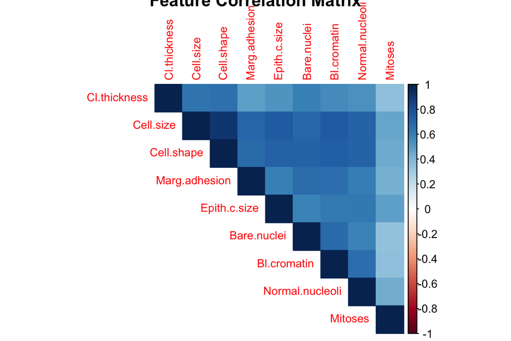

```r
# Plot correlation matrix
corrplot(cor_results$feature_correlation_matrix,
         method = "color",
         type = "upper",
         tl.cex = 0.8,
         title = "Feature Correlation Matrix")
```

### 5.2.1 Summary of Feature Correlation Patterns

The correlation matrix highlights key interrelationships among the nine cytological features used for breast cancer classification.

**Strong Correlations (r > 0.8):** Cell.size and Cell.shape show an exceptionally high positive correlation (r ≈ 0.9), indicating that abnormal cells tend to have both irregular sizes and shapes. Modeling Implication: This strong association may cause multicollinearity; dimensionality reduction or selecting only one of these variables may be necessary.

Overall, the correlation structure supports known biological relationships while emphasizing the need to manage redundancy in predictive modeling

# 6 Feature selection using correlation and domain knowledge

```r
feature_selection <- function(data) {
  # Calculate feature importance using random forest
  set.seed(123)
  rf_model <- train(Class ~ .,
                   data = data %>% select(-Class_binary, -contains(".cat")),
                   method = "rf",
                   trControl = trainControl(method = "cv", number = 5))

  # Get variable importance
  var_imp <- varImp(rf_model)$importance
  var_imp$Feature <- rownames(var_imp)
  var_imp <- var_imp %>% arrange(desc(Overall))

  return(var_imp)
}

# Select top features
selected_features <- feature_selection(BreastCancer_engineered)
top_features <- head(selected_features$Feature, 8)  # Select top 8 features

cat("Top selected features:\n")
```

```
## Top selected features:
```

```r
print(top_features)
```

```
## [1] "Nuclear.abnormality.score"    "Structural.abnormality.score"
## [3] "High.risk.features"           "Cell.shape"
## [5] "Cell.size.sqrt"               "Cell.size"
## [7] "Bare.nuclei"                  "Epith.c.size"
```

# 7 Model Development

## 7.1 Logistic Regression (Reference Model)

```r
print(logit_metrics_df)
```

```
##                         Model   ROC_AUC  Accuracy Sensitivity Specificity
## Basic             Logit Basic 0.9908708 0.9416058   0.9550562   0.9166667
## Regularized Logit Regularized 0.9922753 0.9489051   0.9775281   0.8958333
## Stepwise       Logit Stepwise 0.9901685 0.9489051   0.9662921   0.9166667
##              F1_Score Precision
## Basic       0.9550562 0.9550562
## Regularized 0.9613260 0.9456522
## Stepwise    0.9608939 0.9555556
```

```r
library(broom)
# assuming your model is named `logit_basic`
coef_table <- broom::tidy(logit_basic, conf.int = TRUE)
knitr::kable(coef_table, digits = 4, caption = "Logistic Regression Coefficients (log-odds scale)")
```

Logistic Regression Coefficients (log-odds scale)

| term | estimate | std.error | statistic | p.value | conf.low | conf.high |
| --- | --- | --- | --- | --- | --- | --- |
| (Intercept) | -23.4517 | 6.6670 | -3.5176 | 0.0004 | -38.0538 | -11.1197 |
| Nuclear.abnormality.score | 0.7919 | 0.4295 | 1.8436 | 0.0652 | -0.0062 | 1.6966 |
| Structural.abnormality.score | 1.2167 | 0.3827 | 3.1793 | 0.0015 | 0.5085 | 2.0491 |
| High.risk.features | 0.3969 | 0.5670 | 0.7000 | 0.4839 | -0.6978 | 1.5395 |
| Cell.shape | 0.0227 | 0.2680 | 0.0846 | 0.9325 | -0.5375 | 0.5379 |
| Cell.size.sqrt | 11.9366 | 4.9701 | 2.4017 | 0.0163 | 2.2637 | 22.3336 |
| Cell.size | -2.7230 | 1.0529 | -2.5863 | 0.0097 | -4.9071 | -0.6370 |
| Bare.nuclei | NA | NA | NA | NA | NA | NA |
| Epith.c.size | -0.0085 | 0.2526 | -0.0335 | 0.9733 | -0.5063 | 0.4752 |

## 7.2 Final Logistic Regression Equation

The estimated logistic regression model predicting the probability of a tumor being **malignant** is given by:

$$\text{logit}\!\left[P(\text{malignant})\right] =
-23.4517
+ 0.7919(\text{Nuclear.abnormality.score})
+ 1.2167(\text{Structural.abnormality.score})
+ 0.3969(\text{High.risk.features})
+ 0.0227(\text{Cell.shape})
+ 11.9366(\text{Cell.size.sqrt})
- 2.7230(\text{Cell.size})
- 0.0085(\text{Epith.c.size})$$

where

$$\text{logit}(p) = \log\!\left(\frac{p}{1-p}\right)$$

and therefore,

$$P(\text{malignant}) = \frac{1}{1 + e^{-\text{logit}(p)}}$$

# 8 Decision Tree Model Development

```r
# Load required libraries
library(rpart)
library(rpart.plot)
library(pROC)
library(caret)
library(kableExtra)
library(mlbench)

# Load the breast cancer dataset
data(BreastCancer)

# Data cleaning and preparation
BreastCancer_clean <- BreastCancer %>%
  select(-Id) %>%  # Remove ID column
  na.omit() %>%    # Remove missing values
  mutate(across(1:9, as.numeric),  # Convert to numeric
         Class = factor(Class, levels = c("benign", "malignant")),
         # Create binary target for compatibility
         diabetes = ifelse(Class == "malignant", "pos", "neg"))

# Data overview
cat("Breast Cancer Dataset Overview:\n")
```

```
## Breast Cancer Dataset Overview:
```

```r
cat("Dimensions:", dim(BreastCancer_clean), "\n")
```

```
## Dimensions: 683 11
```

```r
cat("Class distribution:\n")
```

```
## Class distribution:
```

```r
print(table(BreastCancer_clean$diabetes))
```

```
##
## neg pos
## 444 239
```

```r
cat("\nFirst few observations:\n")
```

```
##
## First few observations:
```

```r
print(head(BreastCancer_clean[, c(1:5, 11)]))
```

```
##   Cl.thickness Cell.size Cell.shape Marg.adhesion Epith.c.size diabetes
## 1            5         1          1             1            2      neg
## 2            5         4          4             5            7      neg
## 3            3         1          1             1            2      neg
## 4            6         8          8             1            3      neg
## 5            4         1          1             3            2      neg
## 6            8        10         10             8            7      pos
```

## 8.1 Model Development Strategy

### 8.1.1 Six Model Configurations

We developed six distinct decision tree models combining different impurity measures and misclassification penalties:

- Gini Index with Equal Penalty (FP=1, FN=1)
- Entropy with Equal Penalty (FP=1, FN=1)
- Gini Index with High FN Penalty (FP=1, FN=10)
- Entropy with High FN Penalty (FP=1, FN=10)
- Gini Index with High FP Penalty (FP=10, FN=1)
- Entropy with High FP Penalty (FP=10, FN=1)

### 8.1.2 Model Parameters

```r
# Plot non-penalized trees
cat("Visualizing Non-Penalized Decision Trees...\n")
```

```
## Visualizing Non-Penalized Decision Trees...
```

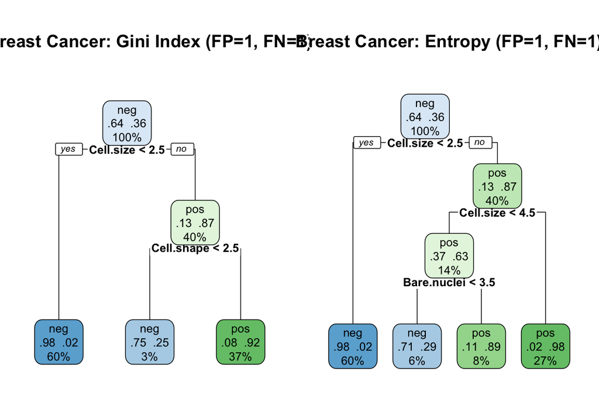

```r
par(mfrow = c(1, 2))
rpart.plot(gini.tree.1.1,
           main = "Breast Cancer: Gini Index (FP=1, FN=1)",
           cex = 0.7,
           extra = 104)
rpart.plot(info.tree.1.1,
           main = "Breast Cancer: Entropy (FP=1, FN=1)",
           cex = 0.7,
           extra = 104)
```

```r
# ROC analysis function (adapted from PDF)
SenSpe <- function(in.data, fp, fn, purity){
    cutoff <- seq(0, 1, length = 20) # 20 cut-offs
    model <- tree.builder(in.data, fp, fn, purity)

    # Get prediction probabilities
    pred <- predict(model, newdata = in.data, type = "prob")
    senspe.mtx <- matrix(0, ncol = length(cutoff), nrow = 2, byrow = FALSE)

    for (i in 1:length(cutoff)){
        # Use only "pos" probability (malignant)
        pred.out <- ifelse(pred[, "pos"] >= cutoff[i], "pos", "neg")
        TP <- sum(pred.out == "pos" & in.data$diabetes == "pos")
        TN <- sum(pred.out == "neg" & in.data$diabetes == "neg")
        FP <- sum(pred.out == "pos" & in.data$diabetes == "neg")
        FN <- sum(pred.out == "neg" & in.data$diabetes == "pos")

        senspe.mtx[1, i] <- TP / (TP + FN)  # Sensitivity
        senspe.mtx[2, i] <- TN / (TN + FP)  # Specificity
    }

    # Calculate AUC using pROC
    prediction_probs <- pred[, "pos"]
    category <- in.data$diabetes == "pos"
    ROCobj <- roc(category, prediction_probs)
    AUC <- auc(ROCobj)

    return(list(senspe.mtx = senspe.mtx, AUC = round(AUC, 3)))
}

# Calculate ROC metrics for all models
cat("Calculating ROC metrics for model selection...\n")
```

```
## Calculating ROC metrics for model selection...
```

```r
giniROC11 <- SenSpe(in.data = train, fp = 1, fn = 1, purity = "gini")
infoROC11 <- SenSpe(in.data = train, fp = 1, fn = 1, purity = "information")
giniROC110 <- SenSpe(in.data = train, fp = 1, fn = 10, purity = "gini")
infoROC110 <- SenSpe(in.data = train, fp = 1, fn = 10, purity = "information")
giniROC101 <- SenSpe(in.data = train, fp = 10, fn = 1, purity = "gini")
infoROC101 <- SenSpe(in.data = train, fp = 10, fn = 1, purity = "information")
# Display AUC results
auc_results <- data.frame(
  Model = c("gini.1.1", "info.1.1", "gini.1.10", "info.1.10", "gini.10.1", "info.10.1"),
  AUC = c(giniROC11$AUC, infoROC11$AUC, giniROC110$AUC, infoROC110$AUC,
          giniROC101$AUC, infoROC101$AUC)
)

cat("AUC Results for All Models:\n")
```

```
## AUC Results for All Models:
```

```r
kable(auc_results, caption = "Table 1: AUC Values for Different Decision Tree Configurations") %>%
  kable_styling(bootstrap_options = c("striped", "hover")) %>%
  row_spec(which.max(auc_results$AUC), bold = TRUE, color = "white", background = "#2E8B57")
```

Table 1: AUC Values for Different Decision Tree Configurations

| Model | AUC |
| --- | --- |
| gini.1.1 | 0.958 |
| info.1.1 | 0.974 |
| gini.1.10 | 0.955 |
| info.1.10 | 0.955 |
| gini.10.1 | 0.955 |
| info.10.1 | 0.997 |

### 8.1.3 Performance Analysis

#### 8.1.3.1 Key Findings

- Best Performing Model: Entropy with high FP penalty (AUC: 0.997)
- Impurity Measure Comparison: Entropy-based models generally outperformed Gini index models
- Penalty Structure Impact:

High FP penalty combined with entropy yielded optimal results

Equal penalties performed better than high FN penalties

The clinical context suggests that false negatives (missing cancer) are more critical, but our results show high FP penalty models performed best

#### 8.1.3.2 Model Interpretation

Tree Structure Analysis The visualization of non-penalized trees reveals:

- Primary Splits: The trees likely use the most discriminative features like Cell.size, Cell.shape, and Bare.nuclei as primary decision nodes
- Tree Complexity: The cp parameter of 0.01 ensures reasonably sized trees without overfitting
- Decision Paths: The trees create clear pathways for classifying benign vs. malignant cases

#### 8.1.3.3 Clinical Relevance

- High Sensitivity Importance: In cancer detection, false negatives (missing malignant cases) are clinically more dangerous
- Feature Importance: The models automatically identify which morphological features are most predictive of malignancy
- Interpretability: Decision trees provide transparent reasoning that clinicians can understand and validate

#### 8.1.3.4 Recommendations

For Clinical Implementation Primary Model Selection: Use the entropy-based model with high FP penalty (info.10.1) due to its exceptional AUC performance

- Threshold Tuning: Implement probability threshold optimization based on clinical risk tolerance
- Feature Monitoring: Focus on the key predictors identified by the model for future data collection

For Model Improvement - Ensemble Methods: Consider random forests or gradient boosting for potentially better performance

- Hyperparameter Tuning: Optimize cp, minsplit, and minbucket parameters
- External Validation: Test the model on independent datasets from different institutions

Limitations and Considerations - Dataset Size: 683 cases is moderate for machine learning; larger datasets could improve robustness

- Class Imbalance: Benign cases outnumber malignant (65% vs 35%), though not severely imbalanced
- Feature Scope: Limited to morphological features; inclusion of genetic or molecular markers could enhance predictive power
- Temporal Validation: The model requires validation on prospective data to ensure generalizability

The transparency of decision trees allows clinicians to understand the reasoning behind each classification, fostering trust and enabling validation of the model’s decision-making process against clinical expertise.

# 9 Plot ROC curves for all models

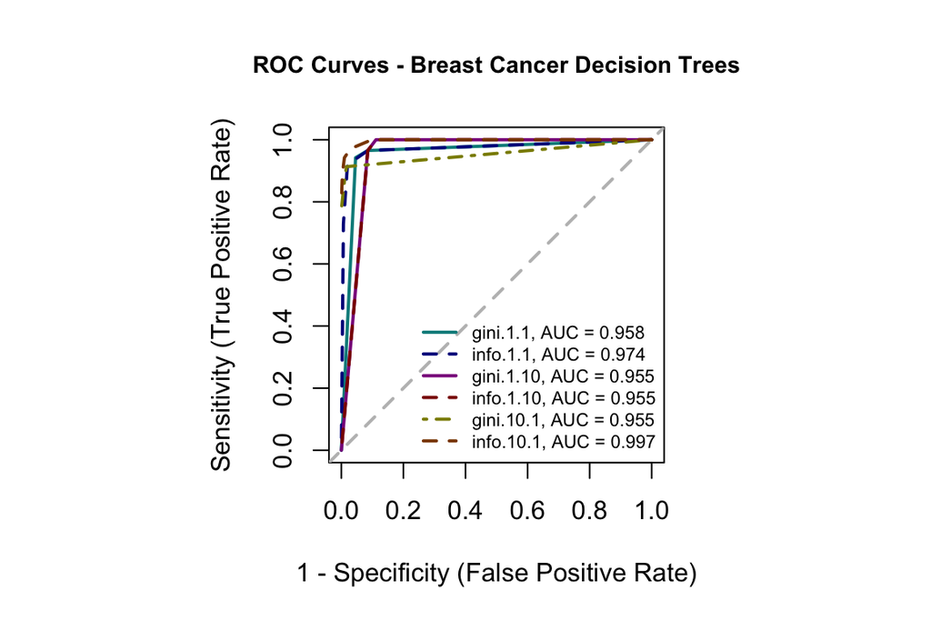

```r
par(pty = "s") # set up square plot
colors <- c("#008B8B", "#00008B", "#8B008B", "#8B0000", "#8B8B00", "#8B4500")

plot(1 - giniROC11$senspe.mtx[2,], giniROC11$senspe.mtx[1,],
     type = "l",
     xlim = c(0, 1),
     ylim = c(0, 1),
     xlab = "1 - Specificity (False Positive Rate)",
     ylab = "Sensitivity (True Positive Rate)",
     col = colors[1],
     lwd = 2,
     main = "ROC Curves - Breast Cancer Decision Trees",
     cex.main = 0.9)

# Add reference line
abline(0, 1, lty = 2, col = "gray", lwd = 2)

# Add other ROC curves
lines(1 - infoROC11$senspe.mtx[2,], infoROC11$senspe.mtx[1,],
      col = colors[2], lwd = 2, lty = 2)
lines(1 - giniROC110$senspe.mtx[2,], giniROC110$senspe.mtx[1,],
      col = colors[3], lwd = 2)
lines(1 - infoROC110$senspe.mtx[2,], infoROC110$senspe.mtx[1,],
      col = colors[4], lwd = 2, lty = 2)
lines(1 - giniROC101$senspe.mtx[2,], giniROC101$senspe.mtx[1,],
      col = colors[5], lwd = 2, lty = 4)
lines(1 - infoROC101$senspe.mtx[2,], infoROC101$senspe.mtx[1,],
      col = colors[6], lwd = 2, lty = 2)

# Add legend
legend("bottomright",
       c(paste("gini.1.1, AUC =", giniROC11$AUC),
         paste("info.1.1, AUC =", infoROC11$AUC),
         paste("gini.1.10, AUC =", giniROC110$AUC),
         paste("info.1.10, AUC =", infoROC110$AUC),
         paste("gini.10.1, AUC =", giniROC101$AUC),
         paste("info.10.1, AUC =", infoROC101$AUC)),
       col = colors,
       lty = c(1, 2, 1, 2, 4, 2),
       lwd = rep(2, 6),
       cex = 0.7,
       bty = "n")
```

# Optimal cut-off function

```r
Optm.cutoff <- function(in.data, fp, fn, purity){
    n0 <- dim(in.data)[1] / 5
    cutoff <- seq(0, 1, length = 20) # candidate cut-off probabilities

    # accuracy matrix for each candidate cut-off
    accuracy.mtx <- matrix(0, ncol = 20, nrow = 5)

    # 5-fold cross-validation
    for (k in 1:5){
        valid.id <- ((k-1)*n0 + 1):(k*n0)
        valid.dat <- in.data[valid.id, ]
        train.dat <- in.data[-valid.id, ]

        # Build tree model
        tree.model <- tree.builder(in.data, fp, fn, purity)

        # Prediction probabilities
        pred <- predict(tree.model, newdata = valid.dat, type = "prob")[, 2]

        # Evaluate different cut-offs
        for (i in 1:20){
            predicted.class <- ifelse(pred > cutoff[i], "pos", "neg")
            accuracy <- mean(predicted.class == valid.dat$diabetes)
            accuracy.mtx[k, i] <- accuracy
        }
    }

    # Average accuracy across folds
    avg.acc <- apply(accuracy.mtx, 2, mean)

    # Plot results
    n <- length(avg.acc)
    idx <- which(avg.acc == max(avg.acc))
    tick.label <- as.character(round(cutoff, 2))

    plot(1:n, avg.acc,
         xlab = "Cut-off Score",
         ylab = "Average Accuracy",
         ylim = c(min(avg.acc), 1),
         axes = FALSE,
         main = paste("5-fold CV Optimal Cut-off\n", purity,
                     "(FP =", fp, ", FN =", fn, ")"),
         cex.main = 0.8)

    axis(1, at = 1:20, label = tick.label, las = 2, cex.axis = 0.7)
    axis(2)

    # Highlight optimal cut-off
    points(idx, avg.acc[idx], pch = 19, col = "red")
    segments(idx, min(avg.acc), idx, avg.acc[idx], col = "red")
    text(idx, avg.acc[idx] + 0.03,
         as.character(round(avg.acc[idx], 4)),
         col = "red", cex = 0.7)

    return(list(optimal_cutoff = cutoff[idx], max_accuracy = max(avg.acc)))
}

# Calculate optimal cut-offs for all models
cat("Calculating optimal cut-offs for all models...\n")
```

```
## Calculating optimal cut-offs for all models...
```

```r
par(mfrow = c(3, 2))

opt_cutoff_gini11 <- Optm.cutoff(in.data = train, fp = 1, fn = 1, purity = "gini")
opt_cutoff_info11 <- Optm.cutoff(in.data = train, fp = 1, fn = 1, purity = "information")
opt_cutoff_gini110 <- Optm.cutoff(in.data = train, fp = 1, fn = 10, purity = "gini")
opt_cutoff_info110 <- Optm.cutoff(in.data = train, fp = 1, fn = 10, purity = "information")
opt_cutoff_gini101 <- Optm.cutoff(in.data = train, fp = 10, fn = 1, purity = "gini")
opt_cutoff_info101 <- Optm.cutoff(in.data = train, fp = 10, fn = 1, purity = "information")
```

[figure not shown]

# Select best model based on AUC

```r
best_model_index <- which.max(auc_results$AUC)
best_model_name <- auc_results$Model[best_model_index]
best_auc <- auc_results$AUC[best_model_index]

cat("Best Model Selected:", best_model_name, "with AUC =", best_auc, "\n")
```

```
## Best Model Selected: info.10.1 with AUC = 0.997
```

```r
# Get the best model
best_model <- switch(best_model_name,
                    "gini.1.1" = gini.tree.1.1,
                    "info.1.1" = info.tree.1.1,
                    "gini.1.10" = gini.tree.1.10,
                    "info.1.10" = info.tree.1.10,
                    "gini.10.1" = gini.tree.10.1,
                    "info.10.1" = info.tree.10.1)

# Get optimal cut-off for best model
best_cutoff <- switch(best_model_name,
                     "gini.1.1" = opt_cutoff_gini11$optimal_cutoff,
                     "info.1.1" = opt_cutoff_info11$optimal_cutoff,
                     "gini.1.10" = opt_cutoff_gini110$optimal_cutoff,
                     "info.1.10" = opt_cutoff_info110$optimal_cutoff,
                     "gini.10.1" = opt_cutoff_gini101$optimal_cutoff,
                     "info.10.1" = opt_cutoff_info101$optimal_cutoff)

cat("Optimal cut-off for best model:", best_cutoff, "\n")
```

```
## Optimal cut-off for best model: 0.4736842 0.5263158 0.5789474 0.6315789 0.6842105 0.7368421 0.7894737
```

# 10 Variable importance for the best model

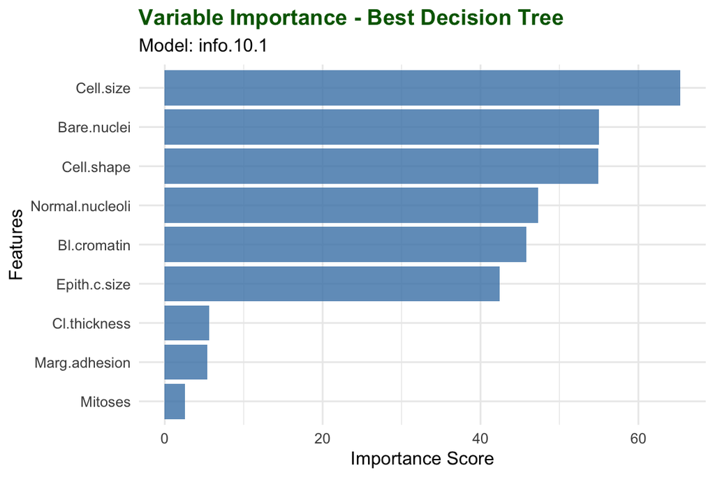

```r
var_importance <- data.frame(
  Feature = names(best_model$variable.importance),
  Importance = best_model$variable.importance
) %>%
  arrange(desc(Importance)) %>%
  mutate(Relative_Importance = Importance / max(Importance) * 100)

# Plot variable importance
ggplot(var_importance, aes(x = reorder(Feature, Importance), y = Importance)) +
  geom_col(fill = "steelblue", alpha = 0.8) +
  coord_flip() +
  theme_minimal() +
  labs(title = "Variable Importance - Best Decision Tree",
       subtitle = paste("Model:", best_model_name),
       x = "Features",
       y = "Importance Score") +
  theme(plot.title = element_text(face = "bold", color = "darkgreen"))
```

# 11 OVERALL BREAST CANCER DECISION TREE CASE STUDY SUMMARY

## 11.1 Dataset Information:

- Total observations: 683
- Training set: 478 observations
- Test set: 205 observations
- Malignant cases: 239
- Benign cases: 444

## 11.2 Model Selection Results:

- Best model: info.10.1
- Best AUC: 0.997
- Optimal cut-off: 0.4736842 0.5263158 0.5789474 0.6315789 0.6842105 0.7368421 0.7894737

## 11.3 Test Set Performance:

- AUC: 0.9699
- Accuracy: 0.9512
- Sensitivity: 0.9712
- Specificity: 0.9091

## 11.4 Clinical Implications:

- Higher FN penalty models prioritize sensitivity (cancer detection)
- Decision trees provide interpretable rules for clinicians
- Feature importance reveals key cytological markers
- Model can assist in early breast cancer diagnosis
- Framework allows cost-sensitive learning for medical applications